# Reallocation Rate Analysis with Interaction Term between Industry Category and Time

The general regression model used in analyzing the effects of different training indices on different reallocation rates is as follow:

$$R_j = \alpha + \beta T_i + \gamma t + \sum_n \delta I_n + \sum_n \lambda_n I_n t$$

- $R =$ *Reallocation Rate*
- $j =$ *Type of reallocation rate*
- $T =$ *Training Index*
- $i =$ *type of training index*
- $t =$ *time, treated as a continuous variable with 2004 denoted as 1 and 2018 denoted as 15*
- $I =$ *industry*
- $n =$ *type of industry based on NAICS Classification*

# Job Reallocation Rate

Job Reallocation Rate refers to total jobs created plus total jobs destroyed, divided by total jobs in the economy. This measure allows us to look at how quickly jobs are reallocated from shrinking firms to expanding ones.

The data source for job reallocation is from the Business Employment Dynamics which collects quarterly job creation and destruction of firms.

Job Reallocation **does not** include workers switching jobs if the job is not created or destroyed.

## Results

### In-Plant/On-Site Training (PT)

```r
lmod <- lm(adj_realloc ~  PT + industryCategory*period.num, t)
summary(lmod)
```

```
Call:
lm(formula = adj_realloc ~ PT + industryCategory * period.num,
    data = t)

Residuals:
     Min       1Q   Median       3Q      Max
-1.54762 -0.27447 -0.00989  0.22250  2.17376

Coefficients:
                               Estimate Std. Error t value Pr(>|t|)
(Intercept)                    44.53581    5.89793   7.551 8.43e-13 ***
PT                              0.06106    1.96107   0.031    0.975
industryCategory21            -33.23786    1.20054 -27.686  < 2e-16 ***
industryCategory22            -39.72003    1.92276 -20.658  < 2e-16 ***
industryCategory23            -20.31841    2.48105  -8.189 1.43e-14 ***
industryCategory31            -36.04279    0.79409 -45.389  < 2e-16 ***
industryCategory42            -33.55651    0.59608 -56.295  < 2e-16 ***
industryCategory44            -30.93434    0.57492 -53.806  < 2e-16 ***
industryCategory48            -33.17344    0.47614 -69.671  < 2e-16 ***
industryCategory51            -35.03275    0.69161 -50.654  < 2e-16 ***
industryCategory52            -34.71379    0.49439 -70.216  < 2e-16 ***
industryCategory53            -29.08317    0.59324 -49.025  < 2e-16 ***
industryCategory54            -29.62746    0.87098 -34.016  < 2e-16 ***
industryCategory55            -37.34222    0.76835 -48.600  < 2e-16 ***
industryCategory56            -25.07805    0.48882 -51.303  < 2e-16 ***
industryCategory61            -31.14762    0.60537 -51.452  < 2e-16 ***
industryCategory62            -36.26562    0.66390 -54.625  < 2e-16 ***
industryCategory71            -15.01751    0.66650 -22.532  < 2e-16 ***
industryCategory72            -28.23789    1.35131 -20.897  < 2e-16 ***
industryCategory81            -28.87834    0.47255 -61.112  < 2e-16 ***
period.num                     -0.65205    0.03484 -18.714  < 2e-16 ***
industryCategory21:period.num   0.69764    0.04941  14.119  < 2e-16 ***
industryCategory22:period.num   0.59975    0.04977  12.051  < 2e-16 ***
industryCategory23:period.num   0.33045    0.04933   6.698 1.42e-10 ***
industryCategory31:period.num   0.49072    0.04924   9.965  < 2e-16 ***
industryCategory42:period.num   0.48628    0.04912   9.901  < 2e-16 ***
industryCategory44:period.num   0.47130    0.04911   9.596  < 2e-16 ***
industryCategory48:period.num   0.57725    0.04915  11.745  < 2e-16 ***
industryCategory51:period.num   0.69505    0.04957  14.022  < 2e-16 ***
industryCategory52:period.num   0.45541    0.05008   9.094  < 2e-16 ***
industryCategory53:period.num   0.46047    0.05057   9.105  < 2e-16 ***
industryCategory54:period.num   0.45040    0.05015   8.981  < 2e-16 ***
industryCategory55:period.num   0.55988    0.04912  11.398  < 2e-16 ***
industryCategory56:period.num   0.42644    0.04939   8.634 7.56e-16 ***
industryCategory61:period.num   0.58767    0.04911  11.966  < 2e-16 ***
industryCategory62:period.num   0.58633    0.05313  11.036  < 2e-16 ***
industryCategory71:period.num   0.43091    0.04919   8.760 3.22e-16 ***
industryCategory72:period.num   0.50023    0.04948  10.109  < 2e-16 ***
industryCategory81:period.num   0.50409    0.04913  10.261  < 2e-16 ***
---
Signif. codes:  0 ‘***’ 0.001 ‘**’ 0.01 ‘*’ 0.05 ‘.’ 0.1 ‘ ’ 1

Residual standard error: 0.5811 on 246 degrees of freedom
Multiple R-squared:  0.9956,    Adjusted R-squared:  0.9949
F-statistic:  1453 on 38 and 246 DF,  p-value: < 2.2e-16
```

### On-the-Job Training (OJ)

```r
lmod <- lm(adj_realloc ~  OJ + industryCategory*period.num, t)
summary(lmod)
```

```
Call:
lm(formula = adj_realloc ~ OJ + industryCategory * period.num,
    data = t)

Residuals:
     Min       1Q   Median       3Q      Max
-1.51901 -0.27265 -0.01241  0.22898  2.21033

Coefficients:
                               Estimate Std. Error t value Pr(>|t|)
(Intercept)                    53.03502    8.44533   6.280 1.52e-09 ***
OJ                             -2.54083    2.57860  -0.985    0.325
industryCategory21            -31.28610    1.99595 -15.675  < 2e-16 ***
industryCategory22            -36.62121    3.11779 -11.746  < 2e-16 ***
industryCategory23            -16.81400    3.50781  -4.793 2.84e-06 ***
industryCategory31            -34.86083    1.26021 -27.663  < 2e-16 ***
industryCategory42            -33.09353    0.63861 -51.822  < 2e-16 ***
industryCategory44            -31.36493    0.61620 -50.901  < 2e-16 ***
industryCategory48            -33.11469    0.44897 -73.758  < 2e-16 ***
industryCategory51            -34.22974    0.91423 -37.441  < 2e-16 ***
industryCategory52            -34.04918    0.80284 -42.411  < 2e-16 ***
industryCategory53            -28.15372    1.03210 -27.278  < 2e-16 ***
industryCategory54            -27.94672    1.74013 -16.060  < 2e-16 ***
industryCategory55            -36.18894    1.23396 -29.328  < 2e-16 ***
industryCategory56            -25.39281    0.54469 -46.619  < 2e-16 ***
industryCategory61            -30.61463    0.69094 -44.309  < 2e-16 ***
industryCategory62            -36.65890    0.58801 -62.344  < 2e-16 ***
industryCategory71            -15.81278    0.90831 -17.409  < 2e-16 ***
industryCategory72            -30.16335    1.96499 -15.350  < 2e-16 ***
industryCategory81            -28.29836    0.73439 -38.533  < 2e-16 ***
period.num                     -0.65101    0.03467 -18.776  < 2e-16 ***
industryCategory21:period.num   0.70814    0.05020  14.107  < 2e-16 ***
industryCategory22:period.num   0.61865    0.05255  11.774  < 2e-16 ***
industryCategory23:period.num   0.32869    0.04904   6.702 1.39e-10 ***
industryCategory31:period.num   0.50657    0.05155   9.826  < 2e-16 ***
industryCategory42:period.num   0.49452    0.04972   9.946  < 2e-16 ***
industryCategory44:period.num   0.47319    0.04905   9.646  < 2e-16 ***
industryCategory48:period.num   0.57099    0.04942  11.554  < 2e-16 ***
industryCategory51:period.num   0.72470    0.05763  12.575  < 2e-16 ***
industryCategory52:period.num   0.48292    0.05626   8.584 1.05e-15 ***
industryCategory53:period.num   0.47867    0.05225   9.161  < 2e-16 ***
industryCategory54:period.num   0.46446    0.05114   9.082  < 2e-16 ***
industryCategory55:period.num   0.58635    0.05588  10.493  < 2e-16 ***
industryCategory56:period.num   0.43571    0.04988   8.735 3.82e-16 ***
industryCategory61:period.num   0.59709    0.04994  11.957  < 2e-16 ***
industryCategory62:period.num   0.58037    0.04947  11.732  < 2e-16 ***
industryCategory71:period.num   0.43733    0.04944   8.846  < 2e-16 ***
industryCategory72:period.num   0.49825    0.04905  10.158  < 2e-16 ***
industryCategory81:period.num   0.50731    0.04913  10.326  < 2e-16 ***
---
Signif. codes:  0 ‘***’ 0.001 ‘**’ 0.01 ‘*’ 0.05 ‘.’ 0.1 ‘ ’ 1

Residual standard error: 0.58 on 246 degrees of freedom
Multiple R-squared:  0.9956,    Adjusted R-squared:  0.9949
F-statistic:  1459 on 38 and 246 DF,  p-value: < 2.2e-16
```

### Relevant Work Experience (RW)

```r
lmod <- lm(adj_realloc ~  RW + industryCategory*period.num, t)
summary(lmod)
```

```
Call:
lm(formula = adj_realloc ~ RW + industryCategory * period.num,
    data = t)

Residuals:
     Min       1Q   Median       3Q      Max
-1.57232 -0.26458 -0.00861  0.22651  2.16178

Coefficients:
                               Estimate Std. Error t value Pr(>|t|)
(Intercept)                    38.97068    5.85936   6.651 1.87e-10 ***
RW                              1.34866    1.37267   0.983    0.327
industryCategory21            -34.72519    1.61196 -21.542  < 2e-16 ***
industryCategory22            -41.86377    2.28507 -18.321  < 2e-16 ***
industryCategory23            -22.28104    2.12225 -10.499  < 2e-16 ***
industryCategory31            -37.23427    1.31155 -28.389  < 2e-16 ***
industryCategory42            -35.25878    1.80111 -19.576  < 2e-16 ***
industryCategory44            -30.76849    0.48075 -64.002  < 2e-16 ***
industryCategory48            -33.44637    0.52794 -63.352  < 2e-16 ***
industryCategory51            -37.00331    2.07092 -17.868  < 2e-16 ***
industryCategory52            -36.15631    1.54080 -23.466  < 2e-16 ***
industryCategory53            -30.11113    1.14864 -26.215  < 2e-16 ***
industryCategory54            -32.25678    2.73638 -11.788  < 2e-16 ***
industryCategory55            -39.92414    2.68497 -14.870  < 2e-16 ***
industryCategory56            -25.28737    0.49129 -51.472  < 2e-16 ***
industryCategory61            -32.22607    1.19669 -26.929  < 2e-16 ***
industryCategory62            -36.51725    0.50643 -72.107  < 2e-16 ***
industryCategory71            -15.34083    0.54483 -28.157  < 2e-16 ***
industryCategory72            -27.21590    1.16890 -23.283  < 2e-16 ***
industryCategory81            -29.80966    1.05188 -28.339  < 2e-16 ***
period.num                     -0.65028    0.03470 -18.739  < 2e-16 ***
industryCategory21:period.num   0.68067    0.05191  13.112  < 2e-16 ***
industryCategory22:period.num   0.57878    0.05356  10.806  < 2e-16 ***
industryCategory23:period.num   0.32008    0.05011   6.388 8.34e-10 ***
industryCategory31:period.num   0.47423    0.05185   9.147  < 2e-16 ***
industryCategory42:period.num   0.47521    0.05030   9.448  < 2e-16 ***
industryCategory44:period.num   0.46900    0.04907   9.557  < 2e-16 ***
industryCategory48:period.num   0.57269    0.04923  11.633  < 2e-16 ***
industryCategory51:period.num   0.66472    0.05781  11.498  < 2e-16 ***
industryCategory52:period.num   0.43707    0.05256   8.315 6.27e-15 ***
industryCategory53:period.num   0.44786    0.05077   8.822  < 2e-16 ***
industryCategory54:period.num   0.42546    0.05506   7.728 2.78e-13 ***
industryCategory55:period.num   0.52031    0.06346   8.199 1.35e-14 ***
industryCategory56:period.num   0.41428    0.05059   8.188 1.44e-14 ***
industryCategory61:period.num   0.57576    0.05050  11.402  < 2e-16 ***
industryCategory62:period.num   0.56645    0.05328  10.632  < 2e-16 ***
industryCategory71:period.num   0.42486    0.04941   8.598 9.60e-16 ***
industryCategory72:period.num   0.49738    0.04909  10.132  < 2e-16 ***
industryCategory81:period.num   0.49520    0.04984   9.936  < 2e-16 ***
---
Signif. codes:  0 ‘***’ 0.001 ‘**’ 0.01 ‘*’ 0.05 ‘.’ 0.1 ‘ ’ 1

Residual standard error: 0.58 on 246 degrees of freedom
Multiple R-squared:  0.9956,    Adjusted R-squared:  0.9949
F-statistic:  1459 on 38 and 246 DF,  p-value: < 2.2e-16
```

### Required Level of Education (RL)

```r
lmod <- lm(adj_realloc ~  RL + industryCategory*period.num, t)
summary(lmod)
```

```
Call:
lm(formula = adj_realloc ~ RL + industryCategory * period.num,
    data = t)

Residuals:
     Min       1Q   Median       3Q      Max
-1.54676 -0.26824  0.00934  0.22107  2.15683

Coefficients:
                               Estimate Std. Error t value Pr(>|t|)
(Intercept)                    38.43859    2.15121  17.868  < 2e-16 ***
RL                              2.33064    0.78994   2.950  0.00348 **
industryCategory21            -33.96865    0.50980 -66.631  < 2e-16 ***
industryCategory22            -41.99476    0.90434 -46.437  < 2e-16 ***
industryCategory23            -20.28103    0.43904 -46.194  < 2e-16 ***
industryCategory31            -37.06063    0.56252 -65.884  < 2e-16 ***
industryCategory42            -35.76282    0.87065 -41.076  < 2e-16 ***
industryCategory44            -30.66716    0.44887 -68.320  < 2e-16 ***
industryCategory48            -33.23968    0.43951 -75.629  < 2e-16 ***
industryCategory51            -39.24492    1.49891 -26.182  < 2e-16 ***
industryCategory52            -38.09600    1.22957 -30.983  < 2e-16 ***
industryCategory53            -30.67704    0.69921 -43.874  < 2e-16 ***
industryCategory54            -36.32835    2.32092 -15.653  < 2e-16 ***
industryCategory55            -42.31336    1.74750 -24.214  < 2e-16 ***
industryCategory56            -25.92460    0.52317 -49.553  < 2e-16 ***
industryCategory61            -37.75504    2.28631 -16.513  < 2e-16 ***
industryCategory62            -41.35097    1.77357 -23.315  < 2e-16 ***
industryCategory71            -15.89792    0.52777 -30.123  < 2e-16 ***
industryCategory72            -26.98536    0.62001 -43.524  < 2e-16 ***
industryCategory81            -30.12202    0.60963 -49.411  < 2e-16 ***
period.num                     -0.66724    0.03452 -19.329  < 2e-16 ***
industryCategory21:period.num   0.69549    0.04827  14.408  < 2e-16 ***
industryCategory22:period.num   0.59541    0.04829  12.330  < 2e-16 ***
industryCategory23:period.num   0.32364    0.04832   6.698 1.43e-10 ***
industryCategory31:period.num   0.49937    0.04835  10.328  < 2e-16 ***
industryCategory42:period.num   0.49722    0.04841  10.271  < 2e-16 ***
industryCategory44:period.num   0.48320    0.04843   9.976  < 2e-16 ***
industryCategory48:period.num   0.60005    0.04888  12.275  < 2e-16 ***
industryCategory51:period.num   0.71563    0.04878  14.671  < 2e-16 ***
industryCategory52:period.num   0.44849    0.04833   9.280  < 2e-16 ***
industryCategory53:period.num   0.46848    0.04834   9.692  < 2e-16 ***
industryCategory54:period.num   0.50180    0.05135   9.772  < 2e-16 ***
industryCategory55:period.num   0.56128    0.04827  11.628  < 2e-16 ***
industryCategory56:period.num   0.45248    0.04906   9.224  < 2e-16 ***
industryCategory61:period.num   0.58875    0.04827  12.198  < 2e-16 ***
industryCategory62:period.num   0.69667    0.06093  11.434  < 2e-16 ***
industryCategory71:period.num   0.43145    0.04827   8.939  < 2e-16 ***
industryCategory72:period.num   0.51631    0.04858  10.628  < 2e-16 ***
industryCategory81:period.num   0.50718    0.04828  10.505  < 2e-16 ***
---
Signif. codes:  0 ‘***’ 0.001 ‘**’ 0.01 ‘*’ 0.05 ‘.’ 0.1 ‘ ’ 1

Residual standard error: 0.5711 on 246 degrees of freedom
Multiple R-squared:  0.9957,    Adjusted R-squared:  0.9951
F-statistic:  1505 on 38 and 246 DF,  p-value: < 2.2e-16
```

## Interpretation

As the result above shows, across industries and adjusted with time, PT, OJ and RW are not statistically significant indices to explain the drop in job reallocation rate. Nevertheless, the correlation between RL and job reallocation rate is positive and statistically significant. This suggests that a higher level of education could have a positive influence job reallocation within industry.

Most previous literature found that training indices and reallocation rate have a negative relationship. This is true for the economy as a whole as shown in the graph below. Without including the interaction term between time and industry, there is a statistically significant negative relationship with the training indices.

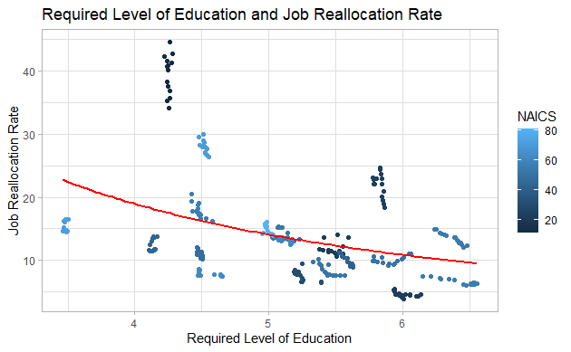

```r
ggplot(data = t) +
  geom_point(mapping = aes(RW, adj_realloc, colour = NAICS)) +
  stat_function(fun = eqn_RW, colour = 'red', size = 1) +
  xlab('Required Level of Education') +
  ylab('Job Reallocation Rate') +
  ggtitle("Required Level of Education and Job Reallocation Rate") +
  theme_light()
```

However, when dummies are included, the relationship holds for some but not for all. In the previous analysis, with only dummy variables for industry categories, RW, OJ and PT have statistically significant negative relationship with job reallocation rate (only RL has an insignificant relationship). Nevertheless, with the addition of the interaction term between industry category and time, RW, OJ and PT has become insignificant explanations for the declining job reallocation rate while RL becomes significant in describing it with a **positive relationship**!

Since the $R^2$ value increased and all of the interactive terms are statistically significant, it is likely that idiosyncracies in the labour market of specific industry as well as another variable that is changing across time could better explain the trend of declining job reallocation rate across time.

In fact, using the regression model:
$$R_{JR} = \alpha + \beta \frac{1}{T_{RL}} + \gamma t + \sum_n \delta I_n + \sum_n \lambda_n I_n t$$
* *JR stands for Job Reallocation*

- *RL stands for Required Level of Education*

gives us a better result. Which suggests that initial increase in Required Level of Education increases the job reallocation significantly but the effect plateaus as Required of Level of Education reaches a point.

```r
lmod <- lm(adj_realloc ~ I(1/RL) + industryCategory*period.num, t)
summary(lmod)
```

```
Call:
lm(formula = adj_realloc ~ I(1/RL) + industryCategory * period.num,
    data = t)

Residuals:
     Min       1Q   Median       3Q      Max
-1.54514 -0.25828  0.00259  0.23165  2.12297

Coefficients:
                               Estimate Std. Error t value Pr(>|t|)
(Intercept)                    63.22984    4.86903  12.986  < 2e-16 ***
I(1/RL)                       -49.89591   13.09851  -3.809 0.000176 ***
industryCategory21            -35.21200    0.68293 -51.560  < 2e-16 ***
industryCategory22            -44.67629    1.38606 -32.233  < 2e-16 ***
industryCategory23            -20.35656    0.43496 -46.801  < 2e-16 ***
industryCategory31            -38.64365    0.81352 -47.502  < 2e-16 ***
industryCategory42            -38.37160    1.33950 -28.646  < 2e-16 ***
industryCategory44            -30.08206    0.48957 -61.446  < 2e-16 ***
industryCategory48            -33.37276    0.43723 -76.328  < 2e-16 ***
industryCategory51            -42.45635    2.00076 -21.220  < 2e-16 ***
industryCategory52            -41.19445    1.75743 -23.440  < 2e-16 ***
industryCategory53            -32.83693    1.07965 -30.414  < 2e-16 ***
industryCategory54            -39.17345    2.54929 -15.366  < 2e-16 ***
industryCategory55            -45.51432    2.19376 -20.747  < 2e-16 ***
industryCategory56            -27.26418    0.71818 -37.963  < 2e-16 ***
industryCategory61            -40.63052    2.53024 -16.058  < 2e-16 ***
industryCategory62            -44.58421    2.22252 -20.060  < 2e-16 ***
industryCategory71            -17.26987    0.73016 -23.652  < 2e-16 ***
industryCategory72            -23.47563    1.33319 -17.609  < 2e-16 ***
industryCategory81            -31.94015    0.91454 -34.925  < 2e-16 ***
period.num                     -0.69526    0.03561 -19.525  < 2e-16 ***
industryCategory21:period.num   0.70211    0.04774  14.707  < 2e-16 ***
industryCategory22:period.num   0.61365    0.04786  12.822  < 2e-16 ***
industryCategory23:period.num   0.31275    0.04795   6.523 3.89e-10 ***
industryCategory31:period.num   0.51962    0.04832  10.754  < 2e-16 ***
industryCategory42:period.num   0.52256    0.04867  10.738  < 2e-16 ***
industryCategory44:period.num   0.50382    0.04848  10.392  < 2e-16 ***
industryCategory48:period.num   0.64282    0.05074  12.669  < 2e-16 ***
industryCategory51:period.num   0.74390    0.04943  15.049  < 2e-16 ***
industryCategory52:period.num   0.47215    0.04792   9.853  < 2e-16 ***
industryCategory53:period.num   0.49020    0.04834  10.140  < 2e-16 ***
industryCategory54:period.num   0.51944    0.05108  10.169  < 2e-16 ***
industryCategory55:period.num   0.59056    0.04840  12.202  < 2e-16 ***
industryCategory56:period.num   0.49472    0.05097   9.707  < 2e-16 ***
industryCategory61:period.num   0.62112    0.04853  12.800  < 2e-16 ***
industryCategory62:period.num   0.72898    0.06056  12.037  < 2e-16 ***
industryCategory71:period.num   0.44138    0.04780   9.233  < 2e-16 ***
industryCategory72:period.num   0.54797    0.04936  11.102  < 2e-16 ***
industryCategory81:period.num   0.52301    0.04798  10.900  < 2e-16 ***
---
Signif. codes:  0 ‘***’ 0.001 ‘**’ 0.01 ‘*’ 0.05 ‘.’ 0.1 ‘ ’ 1

Residual standard error: 0.5647 on 246 degrees of freedom
Multiple R-squared:  0.9958,    Adjusted R-squared:  0.9952
F-statistic:  1539 on 38 and 246 DF,  p-value: < 2.2e-16
```

## Theoretical Explanations

A possible explanation of this phenomenon could come from the fact that employers have little to no incentive in keeping jobs with high level of educational requirement since investment in education is largely done by the employee, not the employer. Hence, the costs of readjusting employment if a mismatch occurs is lower, causing employers to be more willing to fire employees with higher levels education.

It is also possible that mismatch occurs more frequently, given the existence of asymmetric information for general training. Having a degree proves that you could have the relevant skills to do the job but it might turn out to be unsuitable for you.

Nevertheless, these explanations are also applicable to other training indices but there is no statistically significant relationship between them.

Using the formula $Job\ Reallocation = Job\ Creation + Job\ Destruction$, we can decompose job reallocation rates to job creation rates and job destruction rates. The following are the results on performing the regressions using the formula below:

$$R_{job \ creation} = \alpha + \beta T_{RL} + \gamma t + \sum_n \delta I_n + \sum_n \lambda_n I_n t$$

```r
lmod <- lm(gain ~ RL + industryCategory*period.num, t)
summary(lmod)
```

```
Call:
lm(formula = gain ~ RL + industryCategory * period.num, data = t)

Residuals:
     Min       1Q   Median       3Q      Max
-2.01738 -0.17014  0.05622  0.19523  1.47606

Coefficients:
                               Estimate Std. Error t value Pr(>|t|)
(Intercept)                    23.99861    1.57120  15.274  < 2e-16 ***
RL                             -0.62555    0.57695  -1.084    0.279
industryCategory21            -15.40221    0.37235 -41.365  < 2e-16 ***
industryCategory22            -19.14362    0.66051 -28.983  < 2e-16 ***
industryCategory23            -10.45480    0.32066 -32.604  < 2e-16 ***
industryCategory31            -18.10197    0.41085 -44.060  < 2e-16 ***
industryCategory42            -16.09256    0.63590 -25.307  < 2e-16 ***
industryCategory44            -15.44940    0.32785 -47.124  < 2e-16 ***
industryCategory48            -16.66424    0.32101 -51.912  < 2e-16 ***
industryCategory51            -16.53787    1.09477 -15.106  < 2e-16 ***
industryCategory52            -16.46460    0.89805 -18.334  < 2e-16 ***
industryCategory53            -14.13947    0.51069 -27.687  < 2e-16 ***
industryCategory54            -12.63811    1.69515  -7.455 1.53e-12 ***
industryCategory55            -17.33412    1.27633 -13.581  < 2e-16 ***
industryCategory56            -12.13659    0.38211 -31.762  < 2e-16 ***
industryCategory61            -13.29794    1.66987  -7.963 6.19e-14 ***
industryCategory62            -16.43786    1.29538 -12.690  < 2e-16 ***
industryCategory71             -7.29498    0.38547 -18.925  < 2e-16 ***
industryCategory72            -14.31883    0.45284 -31.620  < 2e-16 ***
industryCategory81            -14.06003    0.44526 -31.577  < 2e-16 ***
period.num                     -0.31380    0.02521 -12.446  < 2e-16 ***
industryCategory21:period.num   0.25509    0.03526   7.235 5.89e-12 ***
industryCategory22:period.num   0.28895    0.03527   8.192 1.41e-14 ***
industryCategory23:period.num   0.21096    0.03529   5.978 7.91e-09 ***
industryCategory31:period.num   0.27313    0.03532   7.734 2.68e-13 ***
industryCategory42:period.num   0.24034    0.03536   6.798 7.99e-11 ***
industryCategory44:period.num   0.22158    0.03538   6.264 1.67e-09 ***
industryCategory48:period.num   0.31335    0.03570   8.776 2.89e-16 ***
industryCategory51:period.num   0.34989    0.03563   9.821  < 2e-16 ***
industryCategory52:period.num   0.23267    0.03530   6.592 2.63e-10 ***
industryCategory53:period.num   0.24155    0.03530   6.842 6.16e-11 ***
industryCategory54:period.num   0.20089    0.03750   5.356 1.95e-07 ***
industryCategory55:period.num   0.28637    0.03525   8.123 2.21e-14 ***
industryCategory56:period.num   0.20500    0.03583   5.721 3.06e-08 ***
industryCategory61:period.num   0.26806    0.03525   7.604 6.07e-13 ***
industryCategory62:period.num   0.25333    0.04450   5.693 3.55e-08 ***
industryCategory71:period.num   0.22945    0.03525   6.509 4.22e-10 ***
industryCategory72:period.num   0.24619    0.03548   6.938 3.49e-11 ***
industryCategory81:period.num   0.25515    0.03526   7.236 5.86e-12 ***
---
Signif. codes:  0 ‘***’ 0.001 ‘**’ 0.01 ‘*’ 0.05 ‘.’ 0.1 ‘ ’ 1

Residual standard error: 0.4171 on 246 degrees of freedom
Multiple R-squared:  0.9909,    Adjusted R-squared:  0.9895
F-statistic: 704.9 on 38 and 246 DF,  p-value: < 2.2e-16
```

$$R_{job \ destruction} = \alpha + \beta T_{RL} + \gamma t + \sum_n \delta I_n + \sum_n \lambda_n I_n t$$

```r
lmod <- lm(loss ~ RL + industryCategory*period.num, t)
summary(lmod)
```

```
Call:
lm(formula = loss ~ RL + industryCategory * period.num, data = t)

Residuals:
    Min      1Q  Median      3Q     Max
-1.6385 -0.2431 -0.0572  0.1451  4.0756

Coefficients:
                               Estimate Std. Error t value Pr(>|t|)
(Intercept)                    14.43999    2.32989   6.198 2.40e-09 ***
RL                              2.95619    0.85555   3.455 0.000647 ***
industryCategory21            -18.56644    0.55214 -33.626  < 2e-16 ***
industryCategory22            -22.85114    0.97945 -23.331  < 2e-16 ***
industryCategory23             -9.82623    0.47550 -20.665  < 2e-16 ***
industryCategory31            -18.95866    0.60924 -31.119  < 2e-16 ***
industryCategory42            -19.67026    0.94297 -20.860  < 2e-16 ***
industryCategory44            -15.21776    0.48616 -31.302  < 2e-16 ***
industryCategory48            -16.57544    0.47601 -34.821  < 2e-16 ***
industryCategory51            -22.70704    1.62341 -13.987  < 2e-16 ***
industryCategory52            -21.63140    1.33170 -16.243  < 2e-16 ***
industryCategory53            -16.53757    0.75728 -21.838  < 2e-16 ***
industryCategory54            -23.69023    2.51370  -9.424  < 2e-16 ***
industryCategory55            -24.97925    1.89264 -13.198  < 2e-16 ***
industryCategory56            -13.78801    0.56663 -24.334  < 2e-16 ***
industryCategory61            -24.45710    2.47622  -9.877  < 2e-16 ***
industryCategory62            -24.91310    1.92088 -12.970  < 2e-16 ***
industryCategory71             -8.60294    0.57160 -15.051  < 2e-16 ***
industryCategory72            -12.66654    0.67151 -18.863  < 2e-16 ***
industryCategory81            -16.06199    0.66026 -24.327  < 2e-16 ***
period.num                     -0.35344    0.03739  -9.454  < 2e-16 ***
industryCategory21:period.num   0.44041    0.05228   8.424 3.06e-15 ***
industryCategory22:period.num   0.30646    0.05230   5.859 1.48e-08 ***
industryCategory23:period.num   0.11269    0.05233   2.153 0.032266 *
industryCategory31:period.num   0.22624    0.05237   4.320 2.26e-05 ***
industryCategory42:period.num   0.25688    0.05243   4.900 1.74e-06 ***
industryCategory44:period.num   0.26161    0.05246   4.987 1.16e-06 ***
industryCategory48:period.num   0.28670    0.05294   5.415 1.46e-07 ***
industryCategory51:period.num   0.36574    0.05283   6.923 3.82e-11 ***
industryCategory52:period.num   0.21583    0.05234   4.123 5.11e-05 ***
industryCategory53:period.num   0.22694    0.05235   4.335 2.13e-05 ***
industryCategory54:period.num   0.30091    0.05561   5.411 1.49e-07 ***
industryCategory55:period.num   0.27492    0.05228   5.259 3.15e-07 ***
industryCategory56:period.num   0.24748    0.05313   4.658 5.23e-06 ***
industryCategory61:period.num   0.32070    0.05228   6.135 3.39e-09 ***
industryCategory62:period.num   0.44334    0.06599   6.718 1.27e-10 ***
industryCategory71:period.num   0.20200    0.05228   3.864 0.000143 ***
industryCategory72:period.num   0.27013    0.05262   5.134 5.77e-07 ***
industryCategory81:period.num   0.25203    0.05229   4.820 2.52e-06 ***
---
Signif. codes:  0 ‘***’ 0.001 ‘**’ 0.01 ‘*’ 0.05 ‘.’ 0.1 ‘ ’ 1

Residual standard error: 0.6185 on 246 degrees of freedom
Multiple R-squared:  0.9803,    Adjusted R-squared:  0.9773
F-statistic: 322.3 on 38 and 246 DF,  p-value: < 2.2e-16
```

The results show that the main factor behind the positive relationship observed between RL and job reallocation rate is job destruction rate and not job creation rate. This is a little baffling given the general consensus in empirical evidences that the US workforce as a whole is increasingly educated and that employers are looking for highly educated employees.

Nevertheless, most studies look at the labour market as a whole whilst this does not take into account the compositional shift of industries in the economy, only the required level of education of jobs within industries.

# Worker Reallocation Rate

Worker Reallocation refers to the sum of job finding and separations, it is a common measure of labour market fluidity because it tracks not only the creation and destruction of jobs, but also the flow of workers unexplained by job creation and destruction.

Worker reallocation rate is defined as worker reallocation divided by the labour force. The data is collected from JOLTS (Job Openings and Labour Turnover Surveys), which has monthly data on job finding and separations.

For separations, JOLTS categorize them into layoffs and discharges, quits and other separations. This could help us further identify the patterns within the labor market.

## Results

A multiplicative inverse model is used in this analysis as it yields a better R-squared value.

### In-Plant/On-Site Training (PT)

```r
lmod <- lm(realloc_rate ~ I(1/PT^5) + industryCategoryWR*period.num, p)
summary(lmod)
```

```
Call:
lm(formula = realloc_rate ~ I(1/PT^5) + industryCategoryWR *
    period.num, data = p)

Residuals:
    Min      1Q  Median      3Q     Max
-31.976  -4.677   1.083   4.857  21.218

Coefficients:
                                  Estimate Std. Error t value Pr(>|t|)
(Intercept)                      1.048e+02  9.463e+00  11.071  < 2e-16 ***
I(1/PT^5)                       -1.679e+04  4.730e+03  -3.549 0.000485 ***
industryCategoryWR23             6.295e+01  8.289e+00   7.594 1.27e-12 ***
industryCategoryWR31            -1.667e+00  7.540e+00  -0.221 0.825243
industryCategoryWR42             1.133e+01  8.976e+00   1.262 0.208358
industryCategoryWR44             1.078e+02  1.966e+01   5.481 1.30e-07 ***
industryCategoryWR48             3.021e+01  1.106e+01   2.731 0.006906 **
industryCategoryWR51             4.146e-01  8.141e+00   0.051 0.959433
industryCategoryWR52             1.052e+01  1.053e+01   0.999 0.319117
industryCategoryWR53             4.278e+01  8.976e+00   4.766 3.69e-06 ***
industryCategoryWR54             5.541e+01  7.257e+00   7.635 9.99e-13 ***
industryCategoryWR61             3.997e+00  8.901e+00   0.449 0.653944
industryCategoryWR62             6.541e+01  2.255e+01   2.900 0.004162 **
industryCategoryWR71             1.640e+02  2.290e+01   7.163 1.60e-11 ***
industryCategoryWR72             2.818e+02  5.787e+01   4.869 2.32e-06 ***
industryCategoryWR81             4.147e+01  1.118e+01   3.709 0.000271 ***
period.num                       1.625e+00  5.299e-01   3.067 0.002475 **
industryCategoryWR23:period.num -4.075e+00  7.492e-01  -5.439 1.60e-07 ***
industryCategoryWR31:period.num -2.383e+00  7.518e-01  -3.170 0.001771 **
industryCategoryWR42:period.num -2.664e+00  7.509e-01  -3.547 0.000488 ***
industryCategoryWR44:period.num -2.831e+00  7.534e-01  -3.758 0.000227 ***
industryCategoryWR48:period.num -1.281e+00  7.497e-01  -1.708 0.089203 .
industryCategoryWR51:period.num -8.590e-01  7.495e-01  -1.146 0.253203
industryCategoryWR52:period.num -2.864e+00  7.675e-01  -3.732 0.000250 ***
industryCategoryWR53:period.num -4.094e+00  7.667e-01  -5.339 2.59e-07 ***
industryCategoryWR54:period.num -1.186e+00  7.506e-01  -1.580 0.115738
industryCategoryWR61:period.num -1.713e+00  7.507e-01  -2.282 0.023556 *
industryCategoryWR62:period.num -3.501e+00  9.208e-01  -3.802 0.000192 ***
industryCategoryWR71:period.num -2.075e+00  7.665e-01  -2.707 0.007386 **
industryCategoryWR72:period.num -2.078e+00  7.800e-01  -2.664 0.008372 **
industryCategoryWR81:period.num -1.895e+00  7.501e-01  -2.527 0.012305 *
---
Signif. codes:  0 ‘***’ 0.001 ‘**’ 0.01 ‘*’ 0.05 ‘.’ 0.1 ‘ ’ 1

Residual standard error: 8.864 on 194 degrees of freedom
Multiple R-squared:  0.9466,    Adjusted R-squared:  0.9383
F-statistic: 114.5 on 30 and 194 DF,  p-value: < 2.2e-16
```

### On-the-Job Training (OJ)

```r
lmod <- lm(realloc_rate ~ I(1/OJ^5) + industryCategoryWR*period.num, p)
summary(lmod)
```

```
Call:
lm(formula = realloc_rate ~ I(1/OJ^5) + industryCategoryWR *
    period.num, data = p)

Residuals:
     Min       1Q   Median       3Q      Max
-29.1222  -4.8871   0.7607   5.2096  19.9591

Coefficients:
                                  Estimate Std. Error t value Pr(>|t|)
(Intercept)                      1.362e+02  1.384e+01   9.843  < 2e-16 ***
I(1/OJ^5)                       -6.399e+04  1.380e+04  -4.638 6.45e-06 ***
industryCategoryWR23             4.971e+01  9.291e+00   5.350 2.46e-07 ***
industryCategoryWR31             1.466e+01  8.967e+00   1.635 0.103702
industryCategoryWR42             6.098e+01  1.658e+01   3.678 0.000304 ***
industryCategoryWR44             2.026e+02  3.521e+01   5.756 3.32e-08 ***
industryCategoryWR48             1.039e+02  2.352e+01   4.417 1.66e-05 ***
industryCategoryWR51             3.206e+01  1.222e+01   2.625 0.009363 **
industryCategoryWR52             3.748e+01  1.369e+01   2.738 0.006765 **
industryCategoryWR53             6.245e+01  1.097e+01   5.691 4.61e-08 ***
industryCategoryWR54             5.481e+01  6.904e+00   7.939 1.60e-13 ***
industryCategoryWR61             4.901e+01  1.559e+01   3.144 0.001928 **
industryCategoryWR62             1.436e+02  3.398e+01   4.227 3.64e-05 ***
industryCategoryWR71             3.047e+02  4.753e+01   6.411 1.08e-09 ***
industryCategoryWR72             6.341e+02  1.201e+02   5.279 3.46e-07 ***
industryCategoryWR81             7.162e+01  1.486e+01   4.818 2.91e-06 ***
period.num                       1.248e+00  5.233e-01   2.384 0.018073 *
industryCategoryWR23:period.num -3.703e+00  7.370e-01  -5.024 1.14e-06 ***
industryCategoryWR31:period.num -2.501e+00  7.372e-01  -3.392 0.000841 ***
industryCategoryWR42:period.num -2.800e+00  7.367e-01  -3.801 0.000193 ***
industryCategoryWR44:period.num -2.615e+00  7.336e-01  -3.564 0.000460 ***
industryCategoryWR48:period.num -3.185e-01  7.567e-01  -0.421 0.674281
industryCategoryWR51:period.num -2.197e+00  7.817e-01  -2.811 0.005449 **
industryCategoryWR52:period.num -3.531e+00  7.821e-01  -4.515 1.10e-05 ***
industryCategoryWR53:period.num -4.126e+00  7.452e-01  -5.537 9.92e-08 ***
industryCategoryWR54:period.num -1.523e+00  7.344e-01  -2.073 0.039455 *
industryCategoryWR61:period.num -1.910e+00  7.378e-01  -2.589 0.010358 *
industryCategoryWR62:period.num -4.758e-01  7.725e-01  -0.616 0.538713
industryCategoryWR71:period.num -2.459e+00  7.621e-01  -3.227 0.001468 **
industryCategoryWR72:period.num -2.132e+00  7.496e-01  -2.844 0.004937 **
industryCategoryWR81:period.num -1.720e+00  7.335e-01  -2.345 0.020050 *
---
Signif. codes:  0 ‘***’ 0.001 ‘**’ 0.01 ‘*’ 0.05 ‘.’ 0.1 ‘ ’ 1

Residual standard error: 8.679 on 194 degrees of freedom
Multiple R-squared:  0.9488,    Adjusted R-squared:  0.9408
F-statistic: 119.8 on 30 and 194 DF,  p-value: < 2.2e-16
```

### Relevant Work Experience (RW)

```r
lmod <- lm(realloc_rate ~ I(1/RW^5) + industryCategoryWR*period.num, p)
summary(lmod)
```

```
Call:
lm(formula = realloc_rate ~ I(1/RW^5) + industryCategoryWR *
    period.num, data = p)

Residuals:
    Min      1Q  Median      3Q     Max
-33.996  -5.140   1.059   4.607  22.907

Coefficients:
                                  Estimate Std. Error t value Pr(>|t|)
(Intercept)                      1.237e+02  1.158e+01  10.679  < 2e-16 ***
I(1/RW^5)                       -2.185e+05  4.829e+04  -4.525 1.05e-05 ***
industryCategoryWR23             6.589e+01  7.350e+00   8.965 2.62e-16 ***
industryCategoryWR31            -1.613e+00  7.154e+00  -0.225 0.821888
industryCategoryWR42            -1.519e+01  6.805e+00  -2.231 0.026805 *
industryCategoryWR44             1.761e+02  3.032e+01   5.808 2.55e-08 ***
industryCategoryWR48             7.405e+01  1.783e+01   4.153 4.91e-05 ***
industryCategoryWR51            -2.837e+01  7.273e+00  -3.900 0.000132 ***
industryCategoryWR52            -1.557e+01  6.706e+00  -2.321 0.021322 *
industryCategoryWR53             4.157e+01  7.959e+00   5.223 4.51e-07 ***
industryCategoryWR54             2.188e+01  8.623e+00   2.537 0.011954 *
industryCategoryWR61             8.740e-01  7.692e+00   0.114 0.909659
industryCategoryWR62             6.760e+01  1.859e+01   3.636 0.000355 ***
industryCategoryWR71             1.582e+02  1.721e+01   9.191  < 2e-16 ***
industryCategoryWR72             4.611e+02  8.497e+01   5.427 1.70e-07 ***
industryCategoryWR81             3.513e+01  8.691e+00   4.043 7.62e-05 ***
period.num                       1.123e+00  5.293e-01   2.121 0.035166 *
industryCategoryWR23:period.num -3.764e+00  7.377e-01  -5.103 7.93e-07 ***
industryCategoryWR31:period.num -2.270e+00  7.357e-01  -3.085 0.002332 **
industryCategoryWR42:period.num -2.283e+00  7.365e-01  -3.100 0.002223 **
industryCategoryWR44:period.num -2.204e+00  7.392e-01  -2.981 0.003242 **
industryCategoryWR48:period.num -1.016e+00  7.362e-01  -1.379 0.169349
industryCategoryWR51:period.num -1.038e+00  7.355e-01  -1.410 0.159998
industryCategoryWR52:period.num -2.351e+00  7.355e-01  -3.197 0.001622 **
industryCategoryWR53:period.num -3.565e+00  7.353e-01  -4.848 2.55e-06 ***
industryCategoryWR54:period.num -1.184e+00  7.362e-01  -1.608 0.109381
industryCategoryWR61:period.num -1.551e+00  7.353e-01  -2.109 0.036235 *
industryCategoryWR62:period.num -2.872e+00  7.871e-01  -3.648 0.000339 ***
industryCategoryWR71:period.num -1.476e+00  7.353e-01  -2.007 0.046161 *
industryCategoryWR72:period.num -2.853e+00  7.353e-01  -3.881 0.000143 ***
industryCategoryWR81:period.num -1.685e+00  7.355e-01  -2.290 0.023076 *
---
Signif. codes:  0 ‘***’ 0.001 ‘**’ 0.01 ‘*’ 0.05 ‘.’ 0.1 ‘ ’ 1

Residual standard error: 8.7 on 194 degrees of freedom
Multiple R-squared:  0.9485,    Adjusted R-squared:  0.9406
F-statistic: 119.2 on 30 and 194 DF,  p-value: < 2.2e-16
```

### Required Level of Education (RL)

```r
lmod <- lm(realloc_rate ~ I(1/RL^5) + industryCategoryWR*period.num, p)
summary(lmod)
```

```
Call:
lm(formula = realloc_rate ~ I(1/RL^5) + industryCategoryWR *
    period.num, data = p)

Residuals:
    Min      1Q  Median      3Q     Max
-34.724  -4.902   0.543   4.664  25.805

Coefficients:
                                  Estimate Std. Error t value Pr(>|t|)
(Intercept)                      1.535e+02  1.715e+01   8.951 2.85e-16 ***
I(1/RL^5)                       -1.964e+04  4.171e+03  -4.708 4.75e-06 ***
industryCategoryWR23             1.355e+02  1.359e+01   9.969  < 2e-16 ***
industryCategoryWR31            -2.643e+01  7.232e+00  -3.655 0.000331 ***
industryCategoryWR42            -5.656e+01  1.202e+01  -4.704 4.85e-06 ***
industryCategoryWR44             1.380e+02  2.139e+01   6.452 8.61e-10 ***
industryCategoryWR48             5.209e+01  1.305e+01   3.993 9.27e-05 ***
industryCategoryWR51            -8.242e+01  1.571e+01  -5.245 4.07e-07 ***
industryCategoryWR52            -7.968e+01  1.470e+01  -5.420 1.75e-07 ***
industryCategoryWR53            -1.135e+01  9.726e+00  -1.167 0.244810
industryCategoryWR54            -2.747e+01  1.707e+01  -1.609 0.109164
industryCategoryWR61            -9.018e+01  1.704e+01  -5.293 3.24e-07 ***
industryCategoryWR62            -8.184e+01  1.647e+01  -4.968 1.48e-06 ***
industryCategoryWR71             8.127e+01  6.748e+00  12.043  < 2e-16 ***
industryCategoryWR72             4.376e+02  7.670e+01   5.705 4.29e-08 ***
industryCategoryWR81            -1.186e+01  8.119e+00  -1.461 0.145591
period.num                       7.359e-01  5.474e-01   1.344 0.180439
industryCategoryWR23:period.num -5.212e+00  7.739e-01  -6.735 1.81e-10 ***
industryCategoryWR31:period.num -1.611e+00  7.415e-01  -2.173 0.030998 *
industryCategoryWR42:period.num -1.722e+00  7.498e-01  -2.297 0.022701 *
industryCategoryWR44:period.num -2.182e+00  7.365e-01  -2.963 0.003426 **
industryCategoryWR48:period.num  4.855e-01  8.135e-01   0.597 0.551301
industryCategoryWR51:period.num -8.126e-02  7.550e-01  -0.108 0.914391
industryCategoryWR52:period.num -1.601e+00  7.461e-01  -2.146 0.033088 *
industryCategoryWR53:period.num -2.878e+00  7.447e-01  -3.865 0.000152 ***
industryCategoryWR54:period.num -4.575e-01  7.565e-01  -0.605 0.546076
industryCategoryWR61:period.num -7.262e-01  7.526e-01  -0.965 0.335740
industryCategoryWR62:period.num -2.980e-01  7.829e-01  -0.381 0.703869
industryCategoryWR71:period.num -1.361e+00  7.330e-01  -1.857 0.064773 .
industryCategoryWR72:period.num -1.581e+00  7.803e-01  -2.026 0.044126 *
industryCategoryWR81:period.num -1.346e+00  7.377e-01  -1.825 0.069549 .
---
Signif. codes:  0 ‘***’ 0.001 ‘**’ 0.01 ‘*’ 0.05 ‘.’ 0.1 ‘ ’ 1

Residual standard error: 8.666 on 194 degrees of freedom
Multiple R-squared:  0.9489,    Adjusted R-squared:  0.941
F-statistic: 120.1 on 30 and 194 DF,  p-value: < 2.2e-16
```

## Explanations

Including the interaction terms with the analysis of worker reallocation rate yields very interesting results. All of the data points to fact that a higher training indices result to a higher worker reallocation rate. As the exponentiation of the multiplicative inverse increases, the higher the R-squared value (I kept the exponent at 5 for this notebook).

The consensus in existing literature is that workers with higher training tend to have better job security and less unemployment. The results found is counterintuitive but does not necessarily contradict previous findings. It could be the case that workers with higher human capital are more likely to switch jobs as they are often sought out for their expertise. A common externality labour economists studying human capital theory often include in their analysis is the issue of poaching externality, whereby a company trains a worker but then the newly gained human capital is ‘poached’ by another firm. However, this argument requires that the human capital observed has high generality.

It is also important to note about the assumptions behind the findings, as well as the range of training indices changed in each industry. When preparing the data, due to the lack of consistent time series data in training index, the assumption of that each occupation has the same training requirements over time. The observed difference is the compositional shifts of occupations within the industry. The training indices of the industry is the weighted average of the training index of each occupation. We found that there is an increase in most industries for most indices but the range is relatively small, at about 0.1-0.2 over the course of 15 years. Hence, the results should be not be interpreted directly and no conclusion can be made about the effects of training to the reallocation rates.

# Quit Analysis

In the Jobs Opening and Labour Turnover Survey (JOLTS), total separations are divided into three categories, which gives:
$$Total \ Separations = Quits \ + \ Layoffs \ and \ discharges \ + Other \ discharges$$
The relationship we are interested to look further into is the relationship between quits and layoffs to the training indices.

Quits are seen and interpreted as voluntary discharges initiated by the worker and not the firm. Looking at this measurement, we could analyze the behaviour of the worker in relation to their level of training.

## Results

Just like the worker reallocation rate, a multiplicative inverse model is used for the regression.

### In-Plant/On-Site Training (PT)

```r
lmod <- lm(quits ~ I(1/PT^5) + industryCategoryWR*period.num, q)
summary(lmod)
```

```
Call:
lm(formula = quits ~ I(1/PT^5) + industryCategoryWR * period.num,
    data = q)

Residuals:
     Min       1Q   Median       3Q      Max
-10.8729  -2.4142   0.2735   2.4391   9.3495

Coefficients:
                                  Estimate Std. Error t value Pr(>|t|)
(Intercept)                      2.994e+01  4.444e+00   6.737 1.79e-10 ***
I(1/PT^5)                       -7.877e+03  2.221e+03  -3.546 0.000490 ***
industryCategoryWR23             1.038e+00  3.893e+00   0.267 0.790078
industryCategoryWR31             2.711e+00  3.541e+00   0.766 0.444830
industryCategoryWR42             8.622e+00  4.215e+00   2.045 0.042183 *
industryCategoryWR44             4.745e+01  9.232e+00   5.139 6.70e-07 ***
industryCategoryWR48             1.417e+01  5.196e+00   2.727 0.006985 **
industryCategoryWR51             8.454e+00  3.823e+00   2.211 0.028184 *
industryCategoryWR52             1.380e+01  4.945e+00   2.791 0.005774 **
industryCategoryWR53             1.773e+01  4.215e+00   4.205 3.98e-05 ***
industryCategoryWR54             1.470e+01  3.408e+00   4.314 2.55e-05 ***
industryCategoryWR61             6.493e+00  4.180e+00   1.553 0.121972
industryCategoryWR62             3.798e+01  1.059e+01   3.586 0.000425 ***
industryCategoryWR71             4.977e+01  1.075e+01   4.628 6.73e-06 ***
industryCategoryWR72             1.280e+02  2.718e+01   4.710 4.70e-06 ***
industryCategoryWR81             2.296e+01  5.250e+00   4.373 1.99e-05 ***
period.num                       6.177e-01  2.489e-01   2.482 0.013919 *
industryCategoryWR23:period.num -9.028e-01  3.518e-01  -2.566 0.011049 *
industryCategoryWR31:period.num -6.687e-01  3.531e-01  -1.894 0.059720 .
industryCategoryWR42:period.num -6.848e-01  3.527e-01  -1.942 0.053603 .
industryCategoryWR44:period.num -7.732e-01  3.538e-01  -2.186 0.030048 *
industryCategoryWR48:period.num -3.499e-01  3.520e-01  -0.994 0.321500
industryCategoryWR51:period.num -5.830e-01  3.520e-01  -1.656 0.099284 .
industryCategoryWR52:period.num -1.196e+00  3.604e-01  -3.320 0.001076 **
industryCategoryWR53:period.num -1.253e+00  3.601e-01  -3.479 0.000622 ***
industryCategoryWR54:period.num -9.034e-02  3.525e-01  -0.256 0.798002
industryCategoryWR61:period.num -5.628e-01  3.525e-01  -1.596 0.112024
industryCategoryWR62:period.num -1.361e+00  4.325e-01  -3.148 0.001903 **
industryCategoryWR71:period.num -6.996e-01  3.600e-01  -1.943 0.053422 .
industryCategoryWR72:period.num -4.339e-01  3.663e-01  -1.185 0.237661
industryCategoryWR81:period.num -8.181e-01  3.523e-01  -2.322 0.021249 *
---
Signif. codes:  0 ‘***’ 0.001 ‘**’ 0.01 ‘*’ 0.05 ‘.’ 0.1 ‘ ’ 1

Residual standard error: 4.163 on 194 degrees of freedom
Multiple R-squared:  0.8425,    Adjusted R-squared:  0.8181
F-statistic: 34.58 on 30 and 194 DF,  p-value: < 2.2e-16
```

### On-the-Job Training (OJ)

```r
lmod <- lm(quits ~ I(1/OJ^5) + industryCategoryWR*period.num, q)
summary(lmod)
```

```
Call:
lm(formula = quits ~ I(1/OJ^5) + industryCategoryWR * period.num,
    data = q)

Residuals:
     Min       1Q   Median       3Q      Max
-10.3088  -2.6148   0.4449   2.5281   9.7664

Coefficients:
                                  Estimate Std. Error t value Pr(>|t|)
(Intercept)                      4.089e+01  6.588e+00   6.208 3.20e-09 ***
I(1/OJ^5)                       -2.600e+04  6.568e+03  -3.959 0.000106 ***
industryCategoryWR23            -3.290e+00  4.424e+00  -0.744 0.457928
industryCategoryWR31             8.625e+00  4.269e+00   2.020 0.044729 *
industryCategoryWR42             2.749e+01  7.892e+00   3.483 0.000612 ***
industryCategoryWR44             8.190e+01  1.676e+01   4.886 2.15e-06 ***
industryCategoryWR48             4.215e+01  1.120e+01   3.765 0.000221 ***
industryCategoryWR51             2.032e+01  5.816e+00   3.494 0.000589 ***
industryCategoryWR52             2.297e+01  6.518e+00   3.524 0.000530 ***
industryCategoryWR53             2.442e+01  5.224e+00   4.674 5.52e-06 ***
industryCategoryWR54             1.390e+01  3.287e+00   4.229 3.61e-05 ***
industryCategoryWR61             2.351e+01  7.421e+00   3.168 0.001785 **
industryCategoryWR62             6.498e+01  1.618e+01   4.017 8.43e-05 ***
industryCategoryWR71             1.021e+02  2.263e+01   4.511 1.12e-05 ***
industryCategoryWR72             2.584e+02  5.718e+01   4.518 1.08e-05 ***
industryCategoryWR81             3.324e+01  7.076e+00   4.697 4.99e-06 ***
period.num                       4.610e-01  2.492e-01   1.850 0.065800 .
industryCategoryWR23:period.num -7.490e-01  3.509e-01  -2.135 0.034044 *
industryCategoryWR31:period.num -7.022e-01  3.510e-01  -2.001 0.046823 *
industryCategoryWR42:period.num -7.288e-01  3.508e-01  -2.078 0.039051 *
industryCategoryWR44:period.num -6.676e-01  3.493e-01  -1.911 0.057433 .
industryCategoryWR48:period.num  4.724e-02  3.603e-01   0.131 0.895814
industryCategoryWR51:period.num -1.132e+00  3.721e-01  -3.042 0.002674 **
industryCategoryWR52:period.num -1.431e+00  3.723e-01  -3.842 0.000165 ***
industryCategoryWR53:period.num -1.229e+00  3.548e-01  -3.465 0.000653 ***
industryCategoryWR54:period.num -2.376e-01  3.497e-01  -0.679 0.497680
industryCategoryWR61:period.num -6.319e-01  3.512e-01  -1.799 0.073554 .
industryCategoryWR62:period.num -1.249e-02  3.678e-01  -0.034 0.972938
industryCategoryWR71:period.num -8.195e-01  3.628e-01  -2.259 0.025026 *
industryCategoryWR72:period.num -5.041e-01  3.569e-01  -1.413 0.159354
industryCategoryWR81:period.num -7.384e-01  3.492e-01  -2.114 0.035752 *
---
Signif. codes:  0 ‘***’ 0.001 ‘**’ 0.01 ‘*’ 0.05 ‘.’ 0.1 ‘ ’ 1

Residual standard error: 4.132 on 194 degrees of freedom
Multiple R-squared:  0.8448,    Adjusted R-squared:  0.8208
F-statistic:  35.2 on 30 and 194 DF,  p-value: < 2.2e-16
```

### Related Work Experience (RW)

```r
lmod <- lm(quits ~ I(1/RW^5) + industryCategoryWR*period.num, q)
summary(lmod)
```

```
Call:
lm(formula = quits ~ I(1/RW^5) + industryCategoryWR * period.num,
    data = q)

Residuals:
     Min       1Q   Median       3Q      Max
-10.4117  -2.6528   0.3603   2.4958  10.9294

Coefficients:
                                  Estimate Std. Error t value Pr(>|t|)
(Intercept)                      3.619e+01  5.503e+00   6.577 4.36e-10 ***
I(1/RW^5)                       -9.049e+04  2.294e+04  -3.945 0.000112 ***
industryCategoryWR23             3.178e+00  3.492e+00   0.910 0.363916
industryCategoryWR31             2.102e+00  3.399e+00   0.618 0.536973
industryCategoryWR42            -3.503e+00  3.233e+00  -1.083 0.279990
industryCategoryWR44             7.216e+01  1.440e+01   5.010 1.22e-06 ***
industryCategoryWR48             3.062e+01  8.470e+00   3.616 0.000382 ***
industryCategoryWR51            -4.338e+00  3.455e+00  -1.256 0.210803
industryCategoryWR52             1.431e+00  3.186e+00   0.449 0.653738
industryCategoryWR53             1.609e+01  3.781e+00   4.255 3.25e-05 ***
industryCategoryWR54             3.265e-01  4.096e+00   0.080 0.936562
industryCategoryWR61             4.081e+00  3.654e+00   1.117 0.265449
industryCategoryWR62             3.469e+01  8.833e+00   3.928 0.000119 ***
industryCategoryWR71             4.309e+01  8.175e+00   5.270 3.61e-07 ***
industryCategoryWR72             1.911e+02  4.037e+01   4.733 4.25e-06 ***
industryCategoryWR81             1.861e+01  4.129e+00   4.507 1.14e-05 ***
period.num                       4.067e-01  2.514e-01   1.617 0.107428
industryCategoryWR23:period.num -7.719e-01  3.504e-01  -2.203 0.028803 *
industryCategoryWR31:period.num -6.092e-01  3.495e-01  -1.743 0.082896 .
industryCategoryWR42:period.num -5.170e-01  3.499e-01  -1.478 0.141120
industryCategoryWR44:period.num -4.978e-01  3.512e-01  -1.418 0.157940
industryCategoryWR48:period.num -2.347e-01  3.497e-01  -0.671 0.502961
industryCategoryWR51:period.num -6.616e-01  3.494e-01  -1.893 0.059796 .
industryCategoryWR52:period.num -9.516e-01  3.494e-01  -2.723 0.007049 **
industryCategoryWR53:period.num -1.002e+00  3.493e-01  -2.868 0.004595 **
industryCategoryWR54:period.num -9.861e-02  3.497e-01  -0.282 0.778265
industryCategoryWR61:period.num -4.859e-01  3.493e-01  -1.391 0.165754
industryCategoryWR62:period.num -9.960e-01  3.739e-01  -2.664 0.008377 **
industryCategoryWR71:period.num -4.194e-01  3.493e-01  -1.201 0.231283
industryCategoryWR72:period.num -7.974e-01  3.493e-01  -2.283 0.023516 *
industryCategoryWR81:period.num -7.234e-01  3.494e-01  -2.070 0.039734 *
---
Signif. codes:  0 ‘***’ 0.001 ‘**’ 0.01 ‘*’ 0.05 ‘.’ 0.1 ‘ ’ 1

Residual standard error: 4.133 on 194 degrees of freedom
Multiple R-squared:  0.8447,    Adjusted R-squared:  0.8207
F-statistic: 35.18 on 30 and 194 DF,  p-value: < 2.2e-16
```

### Required Level of Education (RL)

```r
lmod <- lm(quits ~ I(1/RL^5) + industryCategoryWR*period.num, q)
summary(lmod)
```

```
Call:
lm(formula = quits ~ I(1/RL^5) + industryCategoryWR * period.num,
    data = q)

Residuals:
     Min       1Q   Median       3Q      Max
-11.3593  -2.6092   0.1124   2.6081   9.5675

Coefficients:
                                  Estimate Std. Error t value Pr(>|t|)
(Intercept)                      3.630e+01  8.368e+00   4.338 2.31e-05 ***
I(1/RL^5)                       -5.041e+03  2.036e+03  -2.476 0.014138 *
industryCategoryWR23             2.322e+01  6.634e+00   3.501 0.000575 ***
industryCategoryWR31            -6.085e+00  3.530e+00  -1.724 0.086303 .
industryCategoryWR42            -1.321e+01  5.868e+00  -2.252 0.025464 *
industryCategoryWR44             4.130e+01  1.044e+01   3.957 0.000106 ***
industryCategoryWR48             1.321e+01  6.368e+00   2.074 0.039383 *
industryCategoryWR51            -1.617e+01  7.669e+00  -2.109 0.036267 *
industryCategoryWR52            -1.541e+01  7.174e+00  -2.147 0.033004 *
industryCategoryWR53            -5.738e-01  4.747e+00  -0.121 0.903899
industryCategoryWR54            -8.459e+00  8.330e+00  -1.015 0.311158
industryCategoryWR61            -2.200e+01  8.315e+00  -2.646 0.008815 **
industryCategoryWR62            -1.603e+01  8.040e+00  -1.994 0.047550 *
industryCategoryWR71             1.204e+01  3.293e+00   3.657 0.000329 ***
industryCategoryWR72             1.246e+02  3.743e+01   3.330 0.001039 **
industryCategoryWR81             2.586e+00  3.962e+00   0.653 0.514833
period.num                       3.780e-01  2.672e-01   1.415 0.158684
industryCategoryWR23:period.num -1.186e+00  3.777e-01  -3.140 0.001952 **
industryCategoryWR31:period.num -4.227e-01  3.619e-01  -1.168 0.244193
industryCategoryWR42:period.num -4.039e-01  3.659e-01  -1.104 0.271112
industryCategoryWR44:period.num -5.467e-01  3.594e-01  -1.521 0.129882
industryCategoryWR48:period.num  1.244e-01  3.970e-01   0.313 0.754376
industryCategoryWR51:period.num -4.014e-01  3.684e-01  -1.090 0.277274
industryCategoryWR52:period.num -7.467e-01  3.641e-01  -2.051 0.041656 *
industryCategoryWR53:period.num -8.174e-01  3.635e-01  -2.249 0.025641 *
industryCategoryWR54:period.num  6.168e-02  3.692e-01   0.167 0.867498
industryCategoryWR61:period.num -2.729e-01  3.673e-01  -0.743 0.458365
industryCategoryWR62:period.num -1.353e-01  3.821e-01  -0.354 0.723701
industryCategoryWR71:period.num -3.939e-01  3.577e-01  -1.101 0.272206
industryCategoryWR72:period.num -4.701e-01  3.808e-01  -1.234 0.218549
industryCategoryWR81:period.num -6.489e-01  3.600e-01  -1.802 0.073051 .
---
Signif. codes:  0 ‘***’ 0.001 ‘**’ 0.01 ‘*’ 0.05 ‘.’ 0.1 ‘ ’ 1

Residual standard error: 4.229 on 194 degrees of freedom
Multiple R-squared:  0.8374,    Adjusted R-squared:  0.8122
F-statistic:  33.3 on 30 and 194 DF,  p-value: < 2.2e-16
```

## Explanations

The results above shows that PT, RW and OJ have a statistically significant positive relationship with quit rates when the interactive term is included. This means that at least part of the relationship between these three training indices and the worker reallocation rates can be explained by a higher rate of quits.

There could be some explanations behind the higher willingness of workers to quit jobs with higher PT, RW and OJ. Assuming that these three indices are considered to be human capital with higher specificity (but not entirely specific), then it is likely that the investment is made on the part of the firm and not the worker, and hence the yield of the match would be obtained by the firm and not the worker. This might result to a lower incentive for the worker to retain their jobs. Coupled with information assymetry, whereby workers know the available wages offered in the labour market to them while the firm does not, this could explain why workers with these higher training indices have lower attachment to their jobs and have a higher willingness to quit.

# Layoff Analysis

Layoffs and Discharges are interpreted as separations that are initiated by the firm, not the employee. From the employees’ perspectives, such a separation is involuntary and looking at this measurement could provide us with insights about the employers’ decision in separation with regards to the level of training.

## Results

A multiplicative inverse model is also used for the following regressions.

### In-Plant/On-Site Training (PT)

```r
lmod <- lm(layoffs ~ I(1/PT^3) + industryCategoryWR*period.num, l)
summary(lmod)
```

```
Call:
lm(formula = layoffs ~ I(1/PT^3) + industryCategoryWR * period.num,
    data = l)

Residuals:
     Min       1Q   Median       3Q      Max
-10.9251  -1.3265  -0.3001   0.7542  20.0997

Coefficients:
                                 Estimate Std. Error t value Pr(>|t|)
(Intercept)                      15.40568    8.35596   1.844 0.066756 .
I(1/PT^3)                       -68.79192  370.34961  -0.186 0.852836
industryCategoryWR23             36.14337    4.27572   8.453 6.70e-15 ***
industryCategoryWR31              2.97587    3.26883   0.910 0.363752
industryCategoryWR42              2.15587    4.13960   0.521 0.603105
industryCategoryWR44             10.00070    8.83631   1.132 0.259127
industryCategoryWR48              4.28332    5.21782   0.821 0.412710
industryCategoryWR51             -1.62560    3.65123  -0.445 0.656657
industryCategoryWR52             -3.87595    4.96119  -0.781 0.435606
industryCategoryWR53              8.68102    4.14504   2.094 0.037531 *
industryCategoryWR54             15.91051    3.06833   5.185 5.40e-07 ***
industryCategoryWR61              0.03002    4.09287   0.007 0.994155
industryCategoryWR62             -1.83292    9.93386  -0.185 0.853804
industryCategoryWR71             37.44954   10.03049   3.734 0.000248 ***
industryCategoryWR72             14.77254   20.48612   0.721 0.471716
industryCategoryWR81              2.81748    5.27424   0.534 0.593818
period.num                        0.50811    0.21171   2.400 0.017340 *
industryCategoryWR23:period.num  -1.58395    0.29919  -5.294 3.22e-07 ***
industryCategoryWR31:period.num  -0.95233    0.30124  -3.161 0.001823 **
industryCategoryWR42:period.num  -0.95539    0.30036  -3.181 0.001710 **
industryCategoryWR44:period.num  -1.02441    0.30098  -3.404 0.000808 ***
industryCategoryWR48:period.num  -0.65310    0.29950  -2.181 0.030412 *
industryCategoryWR51:period.num  -0.36913    0.29931  -1.233 0.218968
industryCategoryWR52:period.num  -0.70992    0.30973  -2.292 0.022976 *
industryCategoryWR53:period.num  -1.19046    0.31050  -3.834 0.000170 ***
industryCategoryWR54:period.num  -0.78313    0.30005  -2.610 0.009761 **
industryCategoryWR61:period.num  -0.57577    0.30020  -1.918 0.056585 .
industryCategoryWR62:period.num  -0.67674    0.36401  -1.859 0.064526 .
industryCategoryWR71:period.num  -0.74692    0.30554  -2.445 0.015395 *
industryCategoryWR72:period.num  -0.92982    0.30344  -3.064 0.002492 **
industryCategoryWR81:period.num  -0.43997    0.29974  -1.468 0.143766
---
Signif. codes:  0 ‘***’ 0.001 ‘**’ 0.01 ‘*’ 0.05 ‘.’ 0.1 ‘ ’ 1

Residual standard error: 3.539 on 194 degrees of freedom
Multiple R-squared:  0.9209,    Adjusted R-squared:  0.9087
F-statistic: 75.32 on 30 and 194 DF,  p-value: < 2.2e-16
```

### On-the-Job Training (OJ)

```r
lmod <- lm(layoffs ~ I(1/OJ^3) + industryCategoryWR*period.num, l)
summary(lmod)
```

```
Call:
lm(formula = layoffs ~ I(1/OJ^3) + industryCategoryWR * period.num,
    data = l)

Residuals:
     Min       1Q   Median       3Q      Max
-10.9242  -1.3222  -0.3248   0.7860  20.0205

Coefficients:
                                 Estimate Std. Error t value Pr(>|t|)
(Intercept)                       26.0088    14.1858   1.833 0.068269 .
I(1/OJ^3)                       -791.5995   918.4863  -0.862 0.389833
industryCategoryWR23              32.6587     5.4748   5.965 1.14e-08 ***
industryCategoryWR31               5.7446     4.5116   1.273 0.204434
industryCategoryWR42               8.7272     8.7301   1.000 0.318716
industryCategoryWR44              22.6951    16.7625   1.354 0.177336
industryCategoryWR48              13.4867    11.9508   1.129 0.260493
industryCategoryWR51               2.9835     6.4701   0.461 0.645224
industryCategoryWR52               1.1665     7.2708   0.160 0.872703
industryCategoryWR53              12.4674     5.7489   2.169 0.031324 *
industryCategoryWR54              16.6186     2.9397   5.653 5.57e-08 ***
industryCategoryWR61               6.1628     8.2354   0.748 0.455163
industryCategoryWR62              10.2328    16.2867   0.628 0.530554
industryCategoryWR71              53.8747    21.3124   2.528 0.012273 *
industryCategoryWR72              47.7318    42.7049   1.118 0.265072
industryCategoryWR81               8.3382     7.8631   1.060 0.290271
period.num                         0.4667     0.2161   2.160 0.032034 *
industryCategoryWR23:period.num   -1.5418     0.3024  -5.099 8.09e-07 ***
industryCategoryWR31:period.num   -0.9784     0.3010  -3.251 0.001357 **
industryCategoryWR42:period.num   -0.9688     0.2994  -3.236 0.001424 **
industryCategoryWR44:period.num   -1.0066     0.2989  -3.368 0.000914 ***
industryCategoryWR48:period.num   -0.5678     0.3136  -1.811 0.071736 .
industryCategoryWR51:period.num   -0.4893     0.3286  -1.489 0.138092
industryCategoryWR52:period.num   -0.8089     0.3265  -2.477 0.014094 *
industryCategoryWR53:period.num   -1.2298     0.3053  -4.028 8.06e-05 ***
industryCategoryWR54:period.num   -0.8057     0.2993  -2.692 0.007733 **
industryCategoryWR61:period.num   -0.5948     0.2999  -1.984 0.048705 *
industryCategoryWR62:period.num   -0.5414     0.3190  -1.697 0.091300 .
industryCategoryWR71:period.num   -0.7808     0.3032  -2.575 0.010763 *
industryCategoryWR72:period.num   -0.8807     0.3062  -2.876 0.004475 **
industryCategoryWR81:period.num   -0.4225     0.2990  -1.413 0.159315
---
Signif. codes:  0 ‘***’ 0.001 ‘**’ 0.01 ‘*’ 0.05 ‘.’ 0.1 ‘ ’ 1

Residual standard error: 3.533 on 194 degrees of freedom
Multiple R-squared:  0.9212,    Adjusted R-squared:  0.909
F-statistic: 75.62 on 30 and 194 DF,  p-value: < 2.2e-16
```

### Related Work Experience (RW)

```r
lmod <- lm(layoffs ~ I(1/RW^3) + industryCategoryWR*period.num, l)
summary(lmod)
```

```
Call:
lm(formula = layoffs ~ I(1/RW^3) + industryCategoryWR * period.num,
    data = l)

Residuals:
     Min       1Q   Median       3Q      Max
-10.9002  -1.3309  -0.2962   0.8341  20.0694

Coefficients:
                                 Estimate Std. Error t value Pr(>|t|)
(Intercept)                       19.8472    11.0392   1.798 0.073750 .
I(1/RW^3)                       -933.5677  1705.0573  -0.548 0.584645
industryCategoryWR23              35.6529     3.3834  10.538  < 2e-16 ***
industryCategoryWR31               3.4648     3.1083   1.115 0.266359
industryCategoryWR42               1.1325     2.8361   0.399 0.690100
industryCategoryWR44              15.7312    13.5927   1.157 0.248564
industryCategoryWR48               7.9671     8.6754   0.918 0.359573
industryCategoryWR51              -3.1003     3.2973  -0.940 0.348261
industryCategoryWR52              -4.4670     2.7376  -1.632 0.104367
industryCategoryWR53               9.4584     3.6800   2.570 0.010913 *
industryCategoryWR54              13.5512     4.6941   2.887 0.004332 **
industryCategoryWR61               0.6646     3.4945   0.190 0.849370
industryCategoryWR62               1.1023     9.0213   0.122 0.902874
industryCategoryWR71              40.0118     8.4064   4.760 3.78e-06 ***
industryCategoryWR72              27.2947    29.8826   0.913 0.362167
industryCategoryWR81               3.6905     4.1435   0.891 0.374206
period.num                         0.4718     0.2206   2.138 0.033731 *
industryCategoryWR23:period.num   -1.5637     0.3010  -5.196 5.14e-07 ***
industryCategoryWR31:period.num   -0.9510     0.2991  -3.180 0.001716 **
industryCategoryWR42:period.num   -0.9359     0.3001  -3.119 0.002093 **
industryCategoryWR44:period.num   -0.9881     0.3040  -3.251 0.001357 **
industryCategoryWR48:period.num   -0.6303     0.3012  -2.093 0.037675 *
industryCategoryWR51:period.num   -0.3849     0.3000  -1.283 0.200987
industryCategoryWR52:period.num   -0.7004     0.2991  -2.342 0.020200 *
industryCategoryWR53:period.num   -1.1741     0.2989  -3.928 0.000119 ***
industryCategoryWR54:period.num   -0.7821     0.2991  -2.615 0.009626 **
industryCategoryWR61:period.num   -0.5673     0.2990  -1.897 0.059287 .
industryCategoryWR62:period.num   -0.6948     0.3163  -2.197 0.029226 *
industryCategoryWR71:period.num   -0.7230     0.2998  -2.412 0.016813 *
industryCategoryWR72:period.num   -0.9187     0.3013  -3.049 0.002614 **
industryCategoryWR81:period.num   -0.4256     0.2996  -1.421 0.157034
---
Signif. codes:  0 ‘***’ 0.001 ‘**’ 0.01 ‘*’ 0.05 ‘.’ 0.1 ‘ ’ 1

Residual standard error: 3.537 on 194 degrees of freedom
Multiple R-squared:  0.921, Adjusted R-squared:  0.9088
F-statistic: 75.43 on 30 and 194 DF,  p-value: < 2.2e-16
```

### Required Level of Education (RL)

```r
lmod <- lm(layoffs ~ I(1/RL^3) + industryCategoryWR*period.num, l)
summary(lmod)
```

```
Call:
lm(formula = layoffs ~ I(1/RL^3) + industryCategoryWR * period.num,
    data = l)

Residuals:
    Min      1Q  Median      3Q     Max
-9.8211 -1.2893 -0.2686  0.7940 19.5513

Coefficients:
                                  Estimate Std. Error t value Pr(>|t|)
(Intercept)                      5.622e+01  1.246e+01   4.510 1.12e-05 ***
I(1/RL^3)                       -1.170e+03  3.408e+02  -3.434 0.000727 ***
industryCategoryWR23             5.304e+01  5.427e+00   9.773  < 2e-16 ***
industryCategoryWR31            -1.884e+00  2.951e+00  -0.638 0.523923
industryCategoryWR42            -1.660e+01  5.916e+00  -2.807 0.005518 **
industryCategoryWR44             3.463e+01  8.070e+00   4.291 2.81e-05 ***
industryCategoryWR48             1.892e+01  5.220e+00   3.624 0.000370 ***
industryCategoryWR51            -3.160e+01  8.992e+00  -3.514 0.000550 ***
industryCategoryWR52            -3.060e+01  8.006e+00  -3.822 0.000178 ***
industryCategoryWR53            -4.022e+00  4.408e+00  -0.912 0.362745
industryCategoryWR54            -1.994e+01  1.069e+01  -1.865 0.063735 .
industryCategoryWR61            -3.595e+01  1.065e+01  -3.377 0.000884 ***
industryCategoryWR62            -3.605e+01  9.808e+00  -3.675 0.000307 ***
industryCategoryWR71             3.394e+01  2.688e+00  12.625  < 2e-16 ***
industryCategoryWR72             8.805e+01  2.259e+01   3.898 0.000134 ***
industryCategoryWR81            -5.646e+00  3.450e+00  -1.636 0.103363
period.num                       2.216e-01  2.215e-01   1.000 0.318428
industryCategoryWR23:period.num -1.853e+00  3.009e-01  -6.158 4.17e-09 ***
industryCategoryWR31:period.num -7.634e-01  2.953e-01  -2.585 0.010460 *
industryCategoryWR42:period.num -7.027e-01  2.993e-01  -2.348 0.019878 *
industryCategoryWR44:period.num -8.461e-01  2.948e-01  -2.871 0.004551 **
industryCategoryWR48:period.num -1.493e-01  3.251e-01  -0.459 0.646531
industryCategoryWR51:period.num -6.636e-02  3.037e-01  -0.219 0.827264
industryCategoryWR52:period.num -5.155e-01  2.951e-01  -1.747 0.082259 .
industryCategoryWR53:period.num -9.737e-01  2.963e-01  -3.286 0.001206 **
industryCategoryWR54:period.num -4.413e-01  3.075e-01  -1.435 0.152765
industryCategoryWR61:period.num -3.087e-01  3.003e-01  -1.028 0.305371
industryCategoryWR62:period.num -1.317e-02  3.428e-01  -0.038 0.969401
industryCategoryWR71:period.num -6.908e-01  2.908e-01  -2.376 0.018484 *
industryCategoryWR72:period.num -5.834e-01  3.084e-01  -1.892 0.060001 .
industryCategoryWR81:period.num -3.118e-01  2.927e-01  -1.065 0.288112
---
Signif. codes:  0 ‘***’ 0.001 ‘**’ 0.01 ‘*’ 0.05 ‘.’ 0.1 ‘ ’ 1

Residual standard error: 3.437 on 194 degrees of freedom
Multiple R-squared:  0.9255,    Adjusted R-squared:  0.9139
F-statistic: 80.28 on 30 and 194 DF,  p-value: < 2.2e-16
```

## Explanations

Interestingly, layoffs and discharges have no statistically significant relationship with OJ, PT and RW but instead, have a positive relationship with RL. This means that it is likely that the observed relationship in worker reallocation rate is dominated by quits for OJ, PT and RW whereas RL is better explained by layoffs.

The results concur with the dataset in the Business Employment Dynamics, whereby the observed relationship between RL and Job Reallocation Rate is primarily driven by Job Destruction. Consequentially, layoffs is the primary factor behind the relationship between worker reallocation rate and RL.